# Assignment 3

Carolina Herrera Figueroa

10/21/2021

# Instructions

Collaborator: Eliza Epstein

Due date: Wednesday 10/27/2021 before class.

Submit your responses as either an HTML file or a PDF file on Canvas. Also, please upload it to your website.

Load the data by using this code (no need to edit it on your end because it’s getting the data from the internet).

```r
library(readr)
dat.crime <- read_delim("http://www.andrew.cmu.edu/user/achoulde/94842/data/crime_simple.txt", delim = "\t")
```

This is a dataset from a textbook by Brian S. Everitt about crime in the US in 1960. The data originate from the Uniform Crime Report of the FBI and other government sources. The data for 47 states of the USA are given.

Here is the codebook:

R: Crime rate: # of offenses reported to police per million population

Age: The number of males of age 14-24 per 1000 population

S: Indicator variable for Southern states (0 = No, 1 = Yes)

Ed: Mean of years of schooling x 10 for persons of age 25 or older

Ex0: 1960 per capita expenditure on police by state and local government

Ex1: 1959 per capita expenditure on police by state and local government

LF: Labor force participation rate per 1000 civilian urban males age 14-24

M: The number of males per 1000 females

N: State population size in hundred thousands

NW: The number of non-whites per 1000 population

U1: Unemployment rate of urban males per 1000 of age 14-24

U2: Unemployment rate of urban males per 1000 of age 35-39

W: Median value of transferable goods and assets or family income in tens of $

X: The number of families per 1000 earning below 1/2 the median income

We are interested in checking whether the reported crime rate (# of offenses reported to police per million population) and the average education (mean number of years of schooling for persons of age 25 or older) are related.

1. How many observations are there in the dataset? To what does each observation correspond?

```r
dim(dat.crime)
```

```
## [1] 47 14
```

```r
head(dat.crime)
```

```
## # A tibble: 6 × 14
##       R   Age     S    Ed   Ex0   Ex1    LF     M     N    NW    U1    U2     W
##   <dbl> <dbl> <dbl> <dbl> <dbl> <dbl> <dbl> <dbl> <dbl> <dbl> <dbl> <dbl> <dbl>
## 1  79.1   151     1    91    58    56   510   950    33   301   108    41   394
## 2 164.    143     0   113   103    95   583  1012    13   102    96    36   557
## 3  57.8   142     1    89    45    44   533   969    18   219    94    33   318
## 4 197.    136     0   121   149   141   577   994   157    80   102    39   673
## 5 123.    141     0   121   109   101   591   985    18    30    91    20   578
## 6  68.2   121     0   110   118   115   547   964    25    44    84    29   689
## # … with 1 more variable: X <dbl>
```

**In the dataset there are 47 rows and 14 columns. The 14 columns correspond to the statistics of 14 different variables that were looked at, from unemployment rate to state population size and crime rate. Each row corresponds to 1 of the 47 states for which data was collected.**

2. Draw a scatterplot of the two variables. Calculate the correlation between the two variables. Can you come up with an explanation for this relationship?

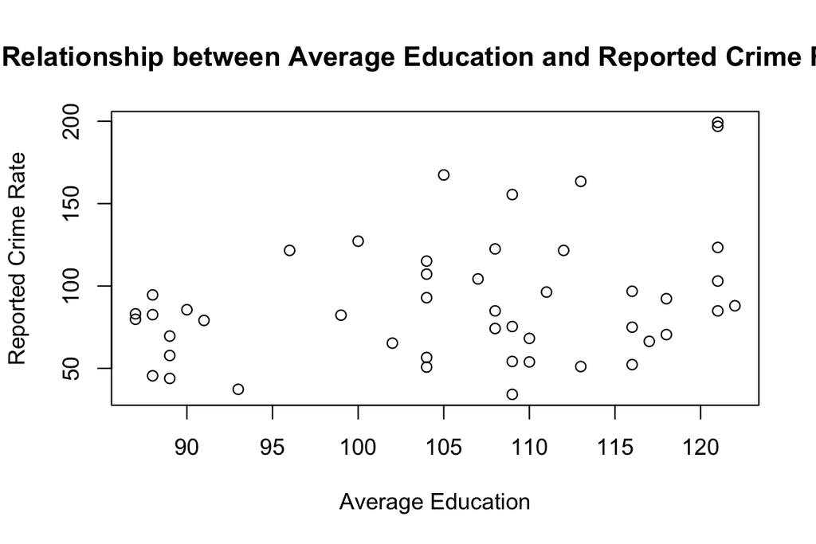

```r
library(datasets)
plot(dat.crime$Ed, dat.crime$R, main= "Relationship between Average Education and Reported Crime Rate",
     xlab = "Average Education", ylab= "Reported Crime Rate")
```

```r
cor(dat.crime$Ed, dat.crime$R)
```

```
## [1] 0.3228349
```

**I would say that there appears to be a weak positive relationship between average education and reported crime rate.The correlation between average education and reported crime rate is 0.3228, which is greater than 0 but still relatively small.**

3. Regress reported crime rate (y) on average education (x) and call this linear model `crime.lm` and write the summary of the regression by using this code, which makes it look a little nicer `{r, eval=FALSE} kable(summary(crime.lm)$coef, digits = 2)`.

```r
crime.lm <-lm(formula = R ~ Ed, data=dat.crime)
```

```r
summary(crime.lm)
```

```
##
## Call:
## lm(formula = R ~ Ed, data = dat.crime)
##
## Residuals:
##     Min      1Q  Median      3Q     Max
## -60.061 -27.125  -4.654  17.133  91.646
##
## Coefficients:
##             Estimate Std. Error t value Pr(>|t|)
## (Intercept) -27.3967    51.8104  -0.529   0.5996
## Ed            1.1161     0.4878   2.288   0.0269 *
## ---
## Signif. codes:  0 '***' 0.001 '**' 0.01 '*' 0.05 '.' 0.1 ' ' 1
##
## Residual standard error: 37.01 on 45 degrees of freedom
## Multiple R-squared:  0.1042, Adjusted R-squared:  0.08432
## F-statistic: 5.236 on 1 and 45 DF,  p-value: 0.02688
```

```r
kable(summary(crime.lm)$coef, digits = 2)
```

[output not shown]

4. Are the four assumptions of linear regression satisfied? To answer this, draw the relevant plots. (Write a maximum of one sentence per assumption.)

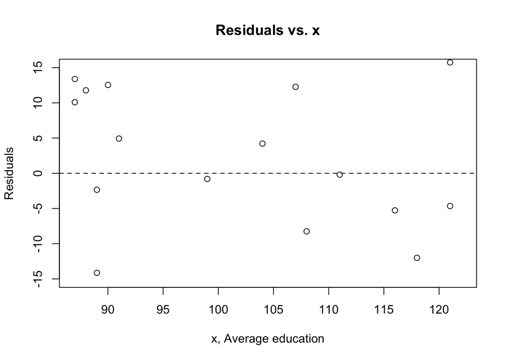

```r
plot(dat.crime$Ed, crime.lm$residuals, ylim=c(-15,15), main= "Residuals vs. x", xlab= "x, Average education", ylab = "Residuals")
abline (h=0, lty="dashed")
```

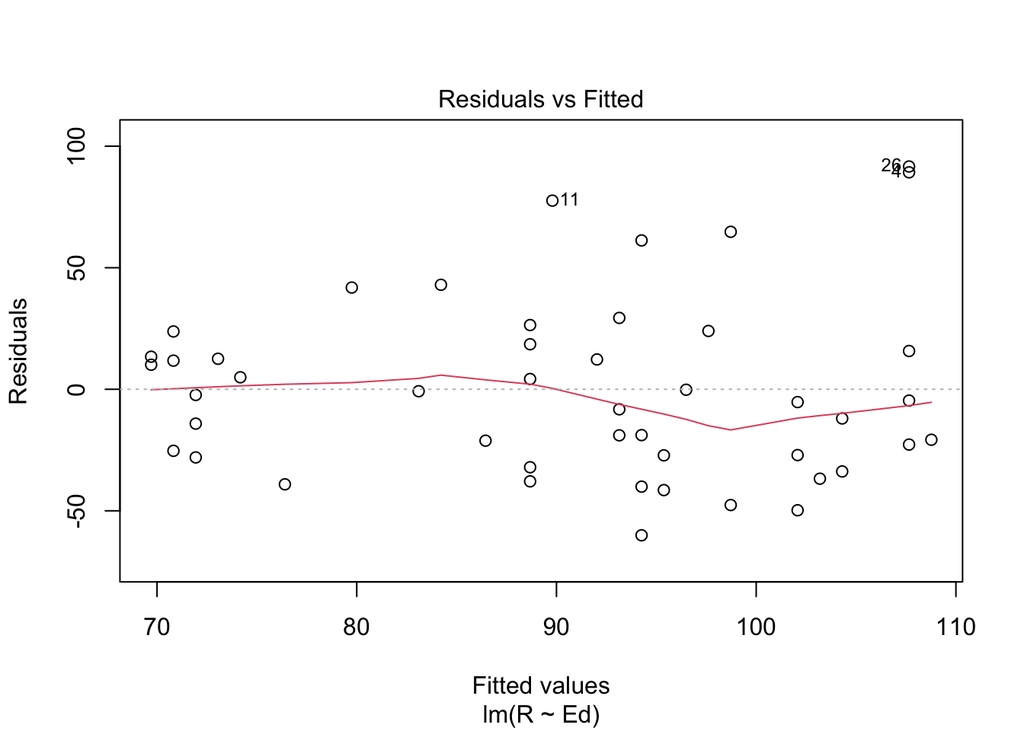

```r
plot(crime.lm, which=1)
```

**The scatterplot for residuals vs x does not have any pattern surrounding the dashed line, thus the linearity assumption is satisfied.**

**Looking at the Residuals vs x plot above, there are no patterns or clumping which would suggest failure of independence, thus the independence assumption is satisfied.**

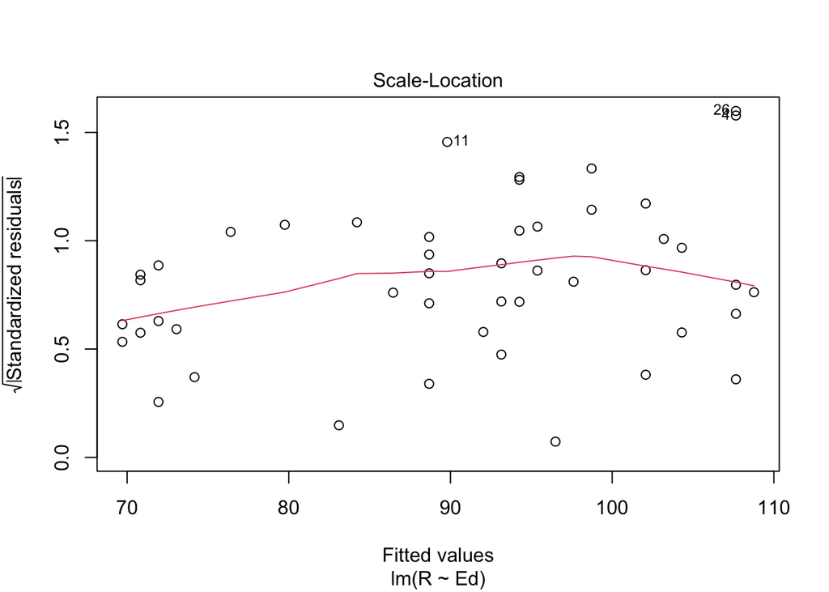

```r
plot(crime.lm, which=3)
```

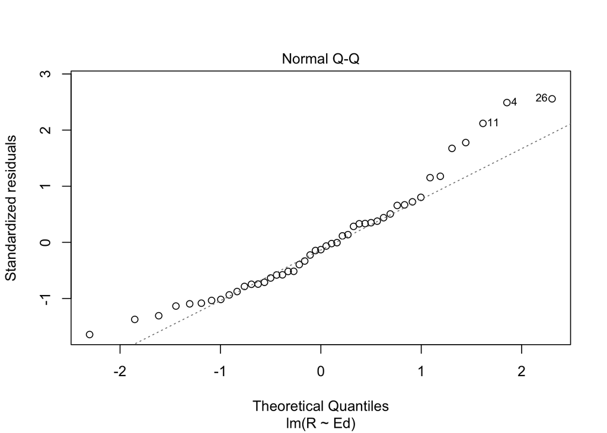

```r
plot(crime.lm, which=2)
```

**The Normal Population Assumption is not fully satisfied because the Q-Q plot does have tails, between -2 and -1, and 1 and 2.**

5. Is the relationship between reported crime and average education statistically significant? Report the estimated coefficient of the slope, the standard error, and the p-value. What does it mean for the relationship to be statistically significant?

**The estimated coefficient of the slope is 1.116, the standard error is 0.4878 and the p-value is 0.0268. Using a significance level of 0.05, the relationship between reported crime and average education is statistically significant because the p-value is smaller than 0.05. Since the relationship is statistically significant we can reject the null hypothesis in favor of the alternative hypothesis, which is that average education and reported crime rate are related. This relationship also isn’t due to chance.**

6. How are reported crime and average education related? In other words, for every unit increase in average education, how does reported crime rate change (per million) per state?

**For every unit increase in education the reported crime rate increases by 1.116 reports per million per state.**

7. Can you conclude that if individuals were to receive more education, then crime will be reported more often? Why or why not?

**Even though the relationship found above was statistically significant I would not conclude that if individuals were to receive more education that crime would be reported more often. We cannot establish a causal relationship between the two, but the model does allow us to make inferences about our population.**